# Holiday Birthdays

Mario Perales

February 17 2016

*Source file* ⇒ Holiday_Birthdays.Rmd

# 1

First, we must initialize our DailyBirths variable. This *R* code will create DailyBirths such that it contains the total number of births across all states for each day in the Birthdays table.

```r
DailyBirths <-
  Birthdays %>%
  group_by(date) %>%
  summarise(total = sum(births))
```

Now, we plot it with the following *R* code:

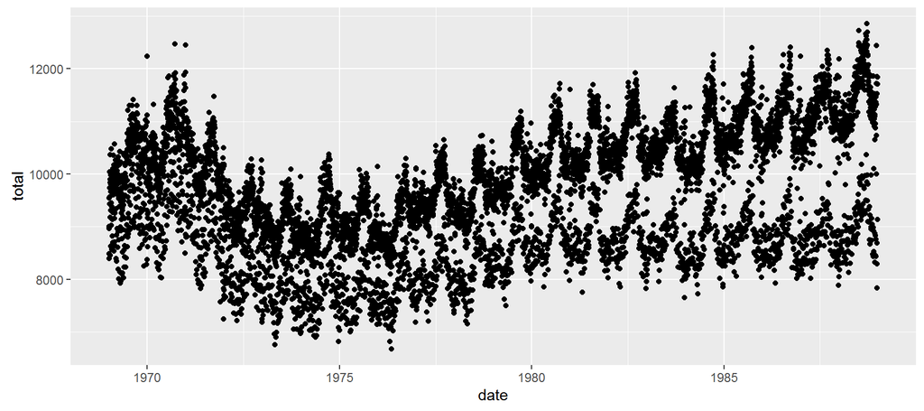

```r
DailyBirths %>%
  ggplot(aes(x = date, y = total)) +
  geom_point()
```

# 2

To get specific cases, we must use the group_by function to condense our data more nicely. To see the birth rate by week, we use the week function as follows:

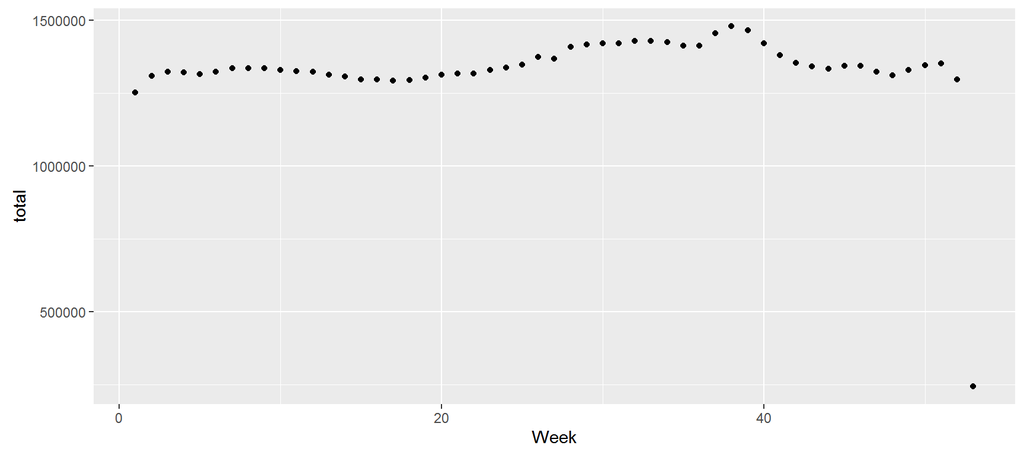

```r
Birthdays %>%
  group_by(week = week(date)) %>%
  summarise(total = sum(births)) %>%
  ggplot(aes(x = week, y = total)) +
  geom_point() +
  xlab("Week")
```

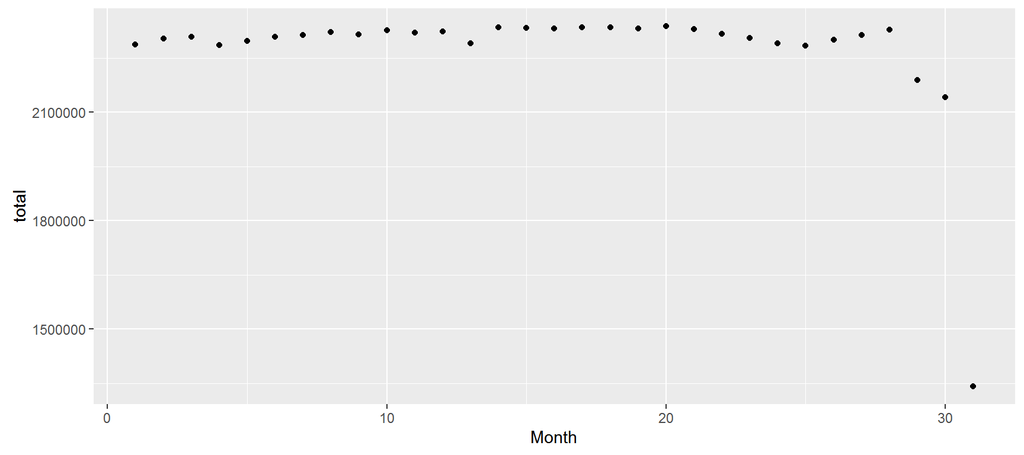

```r
Birthdays %>%
  group_by(month = mday(date)) %>%
  summarise(total = sum(births)) %>%
  ggplot(aes(x = month, y = total)) +
  geom_point() +
  xlab("Month")
```

Lastly, to see the birth rate by day, we use the yday function as follows:

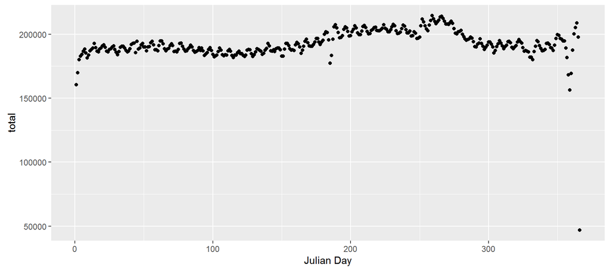

```r
Birthdays %>%
  group_by(julian_day = yday(date)) %>%
  summarise(total = sum(births)) %>%
  ggplot(aes(x = julian_day, y = total)) +
  geom_point() +
  xlab("Julian Day")
```

# 3

As before, since we are just concerned with the births that occured on a given week day, we group our data by week day. Using the wday function as follows gives us the appropriate graph:

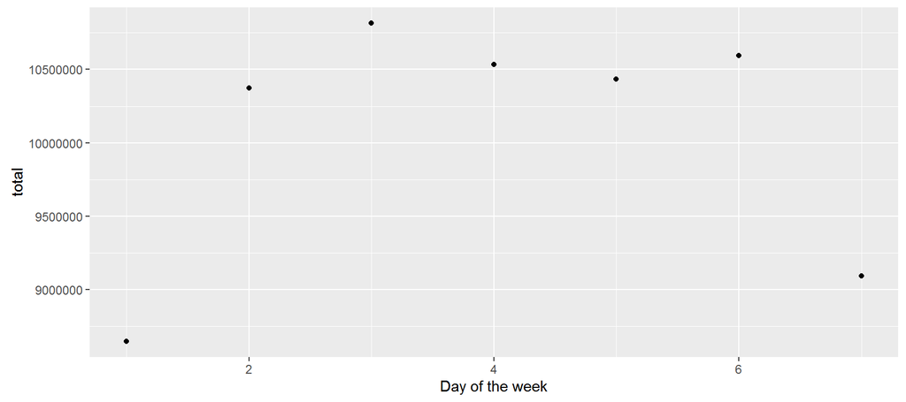

```r
Birthdays %>%
  group_by(day_of_week = wday(date)) %>%
  summarise(total = sum(births)) %>%
  ggplot(aes(x = day_of_week, y = total)) +
  geom_point() +
  xlab("Day of the week")
```

# 4

We now examine data from the years 1980 and 1981. This is done by filtering our data frame as such:

```r
MyTwoYears <-
  Birthdays %>%
  filter(year(date) == 1980 | year(date) == 1981) %>%
  group_by(year,date) %>%
  summarise(total = sum(births))
```

We now plot the total births in this timeframe and also differentiate the days of the week by color. The following *R* code achieves this:

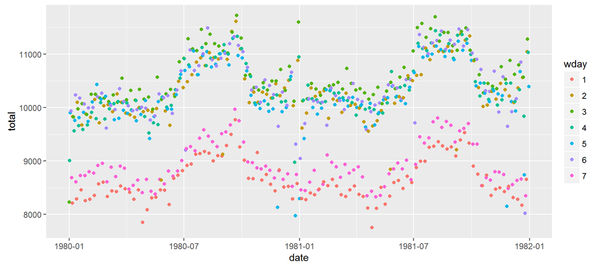

```r
MyTwoYears %>%
  ggplot(aes(x = date, y = total)) +
  geom_point(aes(color = factor(wday(date)))) +
  labs(color = "wday")
```

# 5

We now load the appropriate data which will help us identify the days which are holidays. It is important to note that we must first filter our data such that it corresponds to the interval we are working with (in our case it is from 1980 to 1981). We also arrange the data for simplicity and for further use.

```r
Holidays <- read.csv("http://tiny.cc/dcf/US-Holidays.csv") %>%
  mutate(date = lubridate::dmy(date)) %>%
  filter(year(date) == 1980 | year(date) == 1981) %>%
  arrange(year)
```

# 6

## a

We now add a vertical bar in each holiday using the geom_vline function in *ggplot2*. We first remake our old plot (and this time save it for further use). Then, the following *R* code will generate vertical lines (appropriately associate with the corresponding colors of the day) in the approriate dates which are holidays:

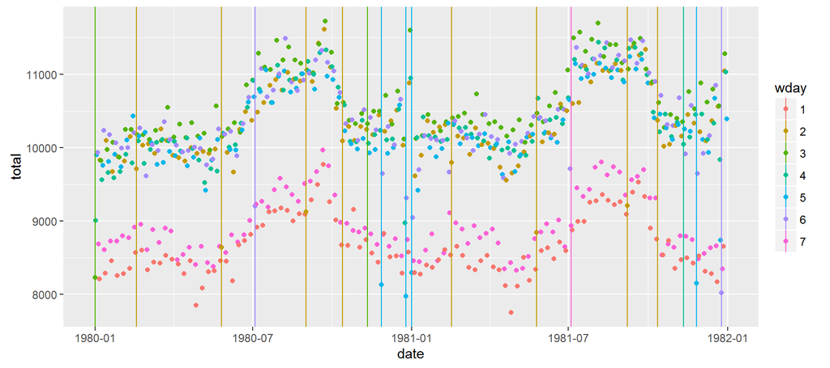

```r
MyTwoYearsPlot <-
  MyTwoYears %>%
  ggplot(aes(x = date, y = total)) +
  geom_point(aes(color = factor(wday(date)))) +
  labs(color = "wday")

MyTwoYearsPlot +
  geom_vline(data = Holidays, aes(xintercept = as.numeric(date), color = factor(wday(date))))
```

## b

Basically the same plot as before, but we add labels to each vertical line which indicates which holiday corresponds to it. We first do this by collecting the names of the holidays, in order of appearance, into a vector and passing that vector into the argumen label in the geom_text function. As personal prefence, we choose appropriate angles and locations for each label. This *R* code achieves all of this:

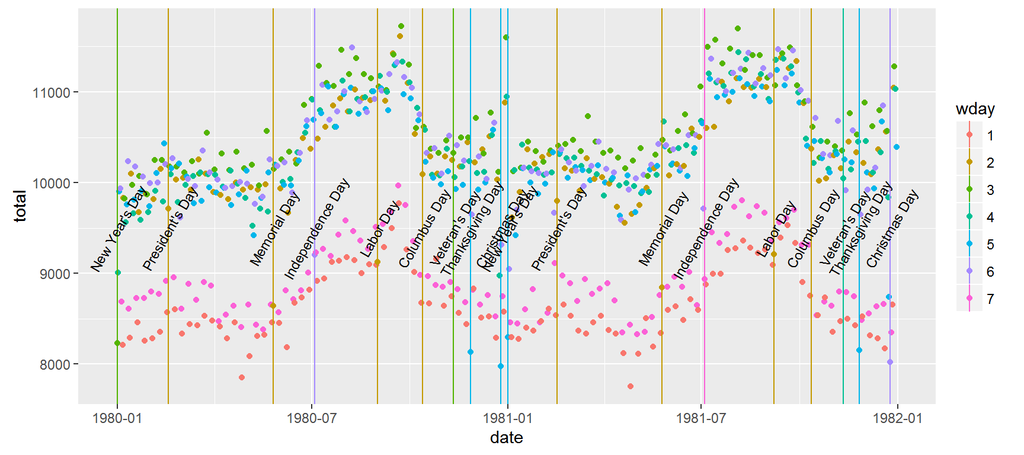

```r
Names <- Holidays$holiday
MyTwoYearsPlot +
  geom_vline(data = Holidays, aes(xintercept = as.numeric(date), color = factor(wday(date)))) +
  geom_text(data = Holidays, aes(x = date, y = 9500, label = Names), angle = 60, size = 3)
```

# 7

We now joing the MyTwoYears and Holidays data frames in such a way that we add a column that corresponds each holiday to the appropriate date and creates the value “NA” if it is not a Holiday. The left_join does this and the following *R* code joins the data frames in such a way:

```r
MyTwoYears <- left_join(MyTwoYears, Holidays)
```

# 8

We now mutate our new holiday column so that it simply reads “yes” if the date is a holiday and “no” if it is not.

```r
MyTwoYears <-
  MyTwoYears %>%
  mutate(is_holiday = ifelse(is.na(holiday),"no","yes"))
```

# 9

We now correspond size with if the date is a holiday. Basically using the same code as before, we get the following graph:

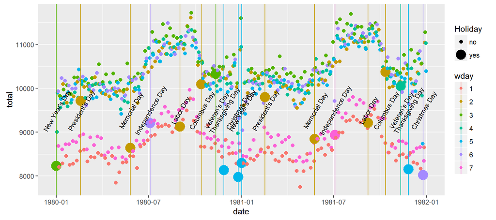

```r
MyTwoYearsPlot <-
  MyTwoYears %>%
  ggplot(aes(x = date, y = total)) +
  geom_point(aes(color = factor(wday(date)), size = is_holiday)) +
  labs(color = "wday", size = "Holiday")

MyTwoYearsPlot +
  geom_vline(data = Holidays, aes(xintercept = as.numeric(date), color = factor(wday(date)))) +
  geom_text(data = Holidays, aes(x = date, y = 9500, label = Names), angle = 60, size = 3)
```

For the most part, it seems as though that the anomalies in the weekdays not corresponding to their average birthrate on that day was due to it being a holiday. For example, Christmas, which occurs in the middle of the week (which is associated with higher birth rates), has one of the lowest birth rates. Most of the holidays exhibit this pattern. However, there are some holidays that do not follow these patterns and their birth rate is on par with the day they land on. These are **Colombus Day**,**Presidents Day** and **Veteran’s Day**.